# Modelagem Conjunta de Dados Longitudinais e de Sobrevivência

Universidade Federal de Minas Gerais (UFMG)

[figure not shown]

## Introdução

## Dado de tempo até o evento

- Acompanha paciente até o evento ou a censura.
- O tempo até o evento é o dado primordial da análise de sobrevivência.
- Importante o tempo que levou para ocorrer o evento.
- Comparação de tratamentos.
- Retorna a função de riscos, a taxa de falha e risco relativo.

## Dado longitudinal

- Valores em diferentes pontos no tempo.
- Importante o valor coletado e o tempo que foi coletado.
- Podem ser ótimos preditores para o tempo até o evento.

## Modelo conjunto

- Modelos clássicos não levam em conta a dependência entre esses dois tipos de dados.
- A modelagem conjunta foi proposta com objetivo de levar em consideração essa dependência.
- Estimativas mais eficientes e menos viesadas.
- Aumento no poder e redução da amostragem.

## Estrutura do modelo conjunto

## Parte longitudinal

O componente longitudinal consiste no modelo linear misto, que pode ser escrito como:

- \(Y_{ij} = X_{ij} +\epsilon_{ij}\);
  - \(Y_{ij}\) é a resposta observada do i-ésimo indivíduo no tempo j-ésimo;
  - \(\epsilon_{ij}\) é o erro aleatório que assumimos que vem de uma distribuição normal;
  - \(X_{ij}\) é conhecida como função trajetória do modelo;

## Função Trajetória

- \(X_{ij} = \theta_{0i} + \theta_{1i} t_{ij} +\gamma Z_i\);
  - \(t_{ij}\) é o valor do tempo;
  - \(Z_i\) é o indicador de tratamento do i-ésimo indivíduo que assume 1 para tratamento e 0 para não tratamento ou tratamento base;
  - \(\theta_{0i}\) e \(\theta_{1i}\) são parâmetros que assumimos como aleatório e com distribuição normal multivariada.
  - \(\gamma\) indica o efeito do tratamento no processo longitudinal.

## Modelo Conjunto

Função de risco do modelo de sobrevivência com o componente longitudinal:

- \(h(t) = h_o(t)exp(\beta X_{ij}+\alpha Z_i)\);
  - \(h(t)\) é a taxa instantânea de ocorrência do evento (função de risco);
  - \(h_o(t)\) é a função de risco de base.
  - \(\alpha\) é o efeito do tratamento no tempo até o evento;
  - \(\beta\) é o efeito do processo longitudinal.

## Efeitos

- Três diferentes efeitos:
  - \(\alpha\) é o efeito do tratamento no tempo até o evento;
  - \(\beta\) é o efeito do processo longitudinal;
  - \(\gamma\) é o efeito do tratamento no processo longitudinal.
- Efeito geral do tratamento:
  - \(\beta\gamma + \alpha\).

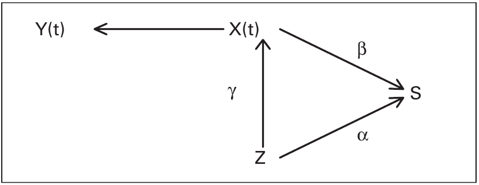

## Interpretações dos efeitos

- \(\beta = 0\): as observações longitudinais não têm associação com o tempo até o evento;
- \(\beta = 0.5\): risco aumenta em 0.5 para cada unidade aumentada em \(X_{ij}\);
- \(\alpha < 0\): risco de quem recebe tratamento \(Z_i = 1\) é menor de quem não recebe \(Z_i = 0\);
- \(\gamma = 0\): o tratamento não influencia os valores dos dados longitudinais.

## Exemplos

## Exemplos

- Qualidade-de-vida (QDV);
  - E1193;
- Simulação.

## *E1193*

- Experimento em grupo E1193 - *Eastern Cooperative Oncology*;
- Examinar a associação entre QDV e tempo de sobrevivência para pacientes no estudo;
- Estudo clínico de fase III de doxorubicin, paclitaxel e uma combinação dos dois;
  - Quimioterapia contra câncer de mama metastático.

## *E1193*

- Pacientes que recebiam um dos dois tratamentos “simples” - doxorubicin ou paclitaxel apenas - trocaram para o outro agente durante o estudo;
- QDV foi acessada por uma escala de avaliação de terapia de câncer de mama (*Brady et al*, 1997);
  - Essa avaliação inclui cinco subescalas gerais:
    - Física;
    - Social;
    - Relacionamento com o médico;
    - Emociona;
    - Funcional.
  - Além de subescalas específicas para câncer de mama.

## *E1193*

- Pontuação máxima de 148 pontos;
  - Quanto maior a pontuação, melhor a qualidade de vida do paciente.
- Análise de:
  - Tempo obrevivência após entrar na fase de cross-over (progressão da doença) e associação com o tratamento e com o QDV.
- QDV;
  - Medida em 2 pontos durante essa fase.

## *E1193*

- 252 pacientes tiveram pelo menos uma medição de QDV realizada.
- 124 pacientes: paclitaxel \(\rightarrow\) doxorubicin;
  - Tempo de vida mediano: 13 meses;
  - 2 censuras.
- 128 pacientes: doxorubicin \(\rightarrow\) paclitaxel;
  - Tempo de vida mediano: 14.9 meses;
  - 6 censuras.

## *E1193*

- Contudo, apenas 65% dos pacientes tiveram 2 medições de QDV realizadas;
  - Esses dados faltantes podem introduzir viés na estimativa do efeito de QDV e do tratamento.
- Dados discrepantes não foram excluídos;
- Essas escolhas foram feitas devido a confiança na habilidade do modelo conjunto em reduzir o viés proveniente de dados incompletos ou com erro.

## Modelos

- Modelo de Cox apenas com a covariável do tratamento;
- Modelo de dois estágios com as duas medidas de QDV:
  - *Tsiatis et al*, 1995;
  - Ajusta um modelo linear misto nos dados longitudinais;
  - Em seguida insere a função trajetória ajustada no modelo de Cox como variável tempo-dependente.
- Modelo conjunto para examinar o efeito do tratamento e a associação entre QDV e a sobrevivência.

## *E1193*

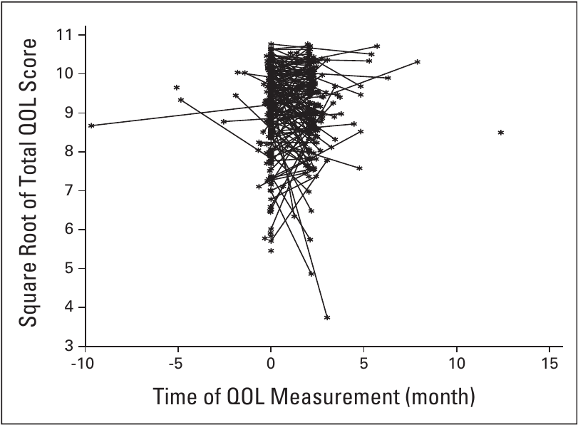

## *E1193*

- Função de trajetória;
  - Muito ruído;
  - Tratar como aleatórias.

## *E1193*: Suposições

- A trajetória de QDV é uma função linear do tempo;
  - Já que temos apenas 2 medidas de QDV.
- A transformação \(QDV^{\frac{1}{2}}\) é normal.
- A interação entre tratamento e tempo foi testada separadamente e foi não-significativa;
  - Podemos assumir que \(QDV^{\frac{1}{2}}\) segue uma trajetória da forma \(\theta_{0i} + \theta_{1i}t + \gamma Tratamento\);
    - No modelo de dois estágios e no modelo conjunto.

## *E1193*: Resultados

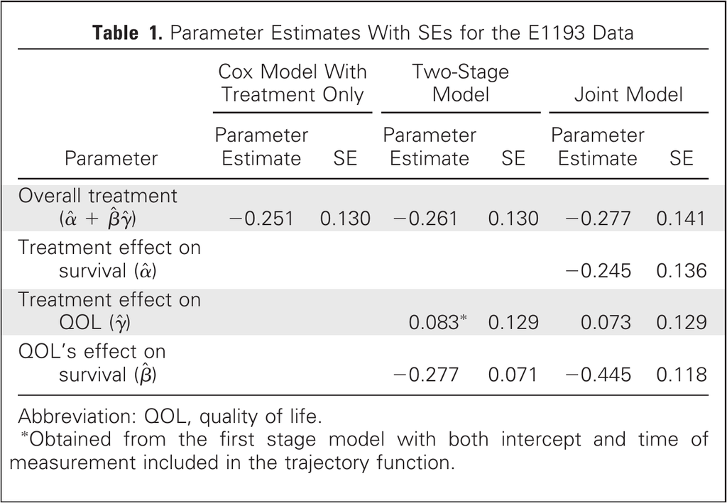

## Simulação

- 12 conjuntos de estudos de simulação com diferentes valores de \(\alpha = (0, 0.5)\), \(\beta = (0, 0.25, 0.5)\) e \(\gamma = (0, 0.5)\);
- Para cada combinação de parâmetros foram usadas 1000 réplicas;
  - Para cada réplica forama gerados 400 indivíduos - 200 no grupo controle e 200 no tratamento.
- A trajetória longitudinal verdadeira foi simulada como: \[X_{ij} = \theta_{0i} + \theta_{1i} \times t_{ij} + \gamma Z_{i},\]

onde \(\theta_{0i} \sim N(0,1), \theta_1 \sim N(0, 0.5^2)\) e \(Cor(\theta_{0i},\theta_{1})=0.3\).

- Os dados longitudinais observados foram simulados de um modelo \[Y_{i}(t_{j}) = N(X_{i}(t_{j}),\sigma_{e}^{2}),\] com \(\sigma_{e}^{2}=0.5^2\);
- O tempo para medidas longitudinais foi fixado em \(t_{j} = (0, 0.5, 1.0, 1.5, 2.0, 2.5)\) anos após a entrada do participante no estudo.

## Simulação

- O tempo de sobrevivência é gerado pela equação: \[h(t) = h_o(t)exp(\beta X_{ij}+\alpha Z_i),\] com \(\lambda(t)=0.25\)
  - Tempo mediano de sobrevivência = 2.77 anos.
- Suposição de censura à direita uniforme;
  - Tempo de *follow-up* mínimo de 1 ano.

## Simulação

- Ajustaram 3 modelos:
  - **A**: Modelo de Cox sem trajetória longitudinal;
  - **B**: Modelo de Cox usando dado longitudinal como variável tempo-dependente;
  - **C**: Modelo conjunto.

## Simulação

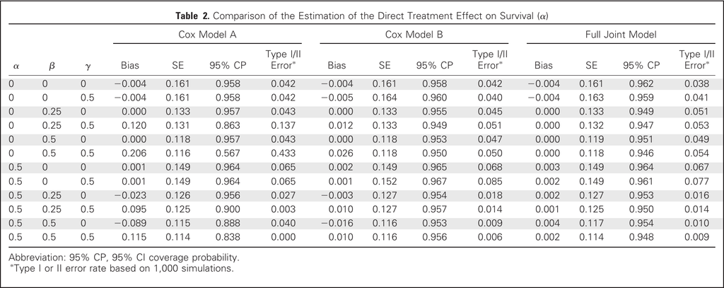

## Simulação

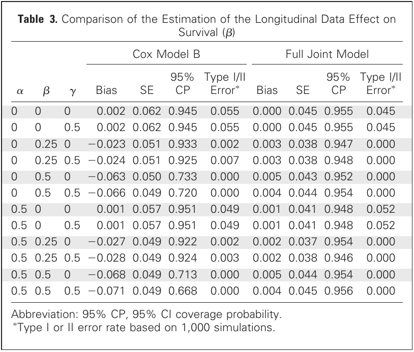

## Discussões

- Quando os dados longitudinais não estão associados ao tratamento \(\gamma = 0\), ignorar a informação longitudinal ainda resultará em estimativas atenuadas do efeito do tratamento;
  - O grau de atenuação depende do grau de associação entre os dados longitudinais e os dados de sobrevivência, \(\beta\);
- A estimativa do efeito do tratamento se mantém sem viés quando não há associação entre os dados longitudinais e de sobrevivência;
- O uso do modelo conjunto no modelamento implica em correção do viés e aumento do poder para estimar o efeito direto do tratamento, \(\alpha\), e o efeito geral do tratamento: \(\beta \gamma + \alpha\).

## Discussões

- Quando o propósito do estudo clínico é investigar o efeito longitudinal no tempo até o evento de interesse, o modelo conjunto leva a estimativas mais eficientes e sem viés quando é ajustado o modelo de sobrevivência correto.

## Referência

- Joseph G. Ibrahim, Haitao Chu and Liddy M. Chen, *Basic Concepts and Methods for Joint Models of Longitudinal and Survival Data*, Journal of Clinical Oncology, 28, 16, (2796), (2010).